# Implementando ICs

Whendell Feijó Magalhães

## Proporção de artistas novos e popularidade

São utilizados ICs para estimar duas métricas (*proporção de novos artistas em geral escutada por usuários* e *correlação entre a popularidade mediana dos artistas escutado e a proporção dos artistas escutados que eram novos*) sobre os usuários do LastFM em geral durante um período de 6 meses. Em ambos os casos as estimações são feitas a partir de uma amostra de 300 usuários.

## Os dados

```r
set.seed(12345)

lastfm = read_csv(here::here("data/experimento-lastfm.csv"),
                  col_types = cols(.default = col_double(),
                                   user = col_character()))

lastfm = lastfm %>%
  sample_n(300) %>%
  select(news, old, mediana_pop)

glimpse(lastfm)
```

```
## Observations: 300
## Variables: 3
## $ news        <dbl> 25, 13, 21, 18, 10, 11, 29, 51, 23, 11, 22, 35, 77, …
## $ old         <dbl> 103, 61, 62, 180, 55, 68, 120, 45, 61, 116, 68, 83, …
## $ mediana_pop <dbl> 5.966097, 5.745970, 5.195969, 5.595928, 5.900597, 6.…
```

### 1. Qual a proporção de novos artistas em geral escutada por usuários?

Inicialmente, foi calculado o $\hat\theta$ (média de novos artistas) da amostra:

```r
calcula_theta = function(df) {
  df %>%
    pull(prop_news) %>%
    mean()
}

lastfm = lastfm %>%
            mutate(prop_news = news / (news + old))

theta_c = calcula_theta(lastfm)
```

Estimando usando uma implementação própria do bootstrap:

```r
repeticoes = 4000 # pelo menos 2000, mas mais não faz mal.

um_bootstrap <- function(x){
  prop_news = x %>% pull(prop_news)
  boot_x <- sample(prop_news,           # amostre dos dados
                   size = NROW(prop_news), # tamanho igual ao recebido
                   replace = TRUE) # aqui é o bootstrap
  return(mean(boot_x))
}

set.seed(1995)

# A REAMOSTRAGEM
reamostragens = tibble(i = 1:repeticoes) %>%
  mutate(theta_c_s = map_dbl(i, ~ um_bootstrap(lastfm)))
```

Definindo o intervalo com 95% de confiança:

```r
intervalo = reamostragens %>%
  mutate(erro = theta_c_s - theta_c) %>%
  summarise(erro_i = quantile(erro, .025),
            erro_s = quantile(erro, .975))

intervalo = intervalo %>%
  mutate(valor_i = theta_c + erro_i,
         valor_s = theta_c + erro_s)
```

Estimando usando o pacote boot:

```r
library(boot)
library(broom)

theta <- function(d, i) {
    agrupado = d %>%
        slice(i) %>%
        pull(prop_news) %>%
        mean()
}

booted <- boot(data = lastfm,
               statistic = theta,
               R = 4000)

ci = tidy(booted,
          conf.level = .95,
          conf.method = "bca",
          conf.int = TRUE)
```

No gráfico podemos visualizar as estimativas calculadas usando uma implementação própria do bootstrap e usando o bootstrap do pacote *boot*:

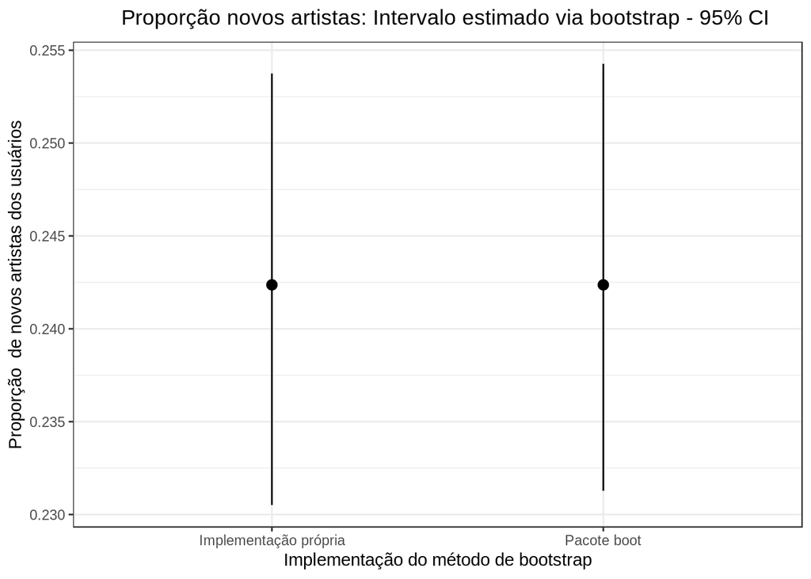

```r
ggplot() +
    geom_pointrange(aes(x = "Implementação própria",
                        y = theta_c,
                        ymin = intervalo$valor_i,
                        ymax = intervalo$valor_s
                    )) +
    geom_pointrange(aes(x = "Pacote boot",
                      y = ci$statistic,
                      ymin = ci$conf.low,
                      ymax = ci$conf.high
                      )) +
    geom_point(size = 3) +
    labs(x = "Implementação do método de bootstrap",
         y = "Proporção  de novos artistas dos usuários",
         title = expression("\tProporção novos artistas: Intervalo estimado via bootstrap - 95% CI"))
```

A patir desta amostra estimamos que a média da proporção de artistas novos consumidos durante 6 meses foi de $ 0.24$, a partir da análise do intervalo podemos inferir que a média desta métrica na população fica entre 0.231 e 0.254, com 95% de confiança. O valores para a implemtantação própria foram: $\hat\theta = 0.242366$, $95\%$ CI [$0.2305119, 0.2537466$] para a implementação própria e $\hat\theta = 0.242366$, $95\%$ CI [$0.2312781, 0.2542668$] para a estimação usando a biblioteca *boot*.

### 2. Para os usuários que gostam de música muito pop (mediana_pop > 5), qual a correlação entre a popularidade mediana dos artistas escutados e a proporção dos artistas escutados que eram novos.

Visualizando a correlação sob os dados da amostra:

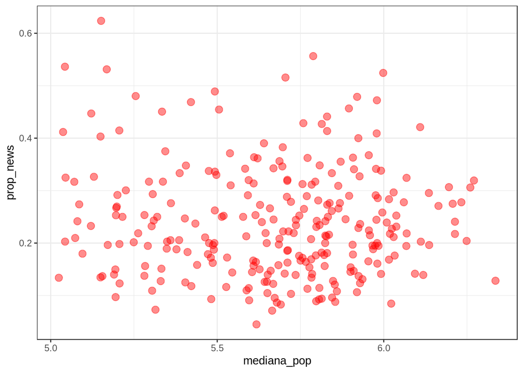

```r
lastfm %>%
  filter(mediana_pop > 5) %>%
    ggplot(aes(x = mediana_pop, y = prop_news)) +
    geom_point(color = "red", size = 3, alpha = 0.45)
```

Calculando o coeficiente de correlação ($\hat\theta$) da amostra e estimando o intervalo de confiança de 95% “manualmente”:

```r
theta_c_2 = lastfm %>%
  filter(mediana_pop > 5) %>%
  summarise(spearman = cor(mediana_pop, prop_news, method = "spearman")) %>%
  pull(spearman)

um_bootstrap_corr <- function(x){
  boot_x <- sample_n(x,           # amostre dos dados
                    size = NROW(x), # tamanho igual ao recebido
                    replace = TRUE) # aqui é o bootstrap
  theta_c_sf <- boot_x %>%
                  filter(mediana_pop > 5) %>%
                  summarise(spearman = cor(mediana_pop,
                                           prop_news,
                                           method = "spearman")) %>%
                  pull(spearman)
  return(theta_c_sf)
}

set.seed(1995)

# A REAMOSTRAGEM
reamostragens_2 = tibble(i = 1:repeticoes) %>%
  mutate(theta_c_s = map_dbl(i, ~ um_bootstrap_corr(lastfm)))

intervalo_2 = reamostragens_2 %>%
  mutate(erro = theta_c_s - theta_c_2) %>%
  summarise(erro_i = quantile(erro, .025),
            erro_s = quantile(erro, .975))

intervalo_2 = intervalo_2 %>%
  mutate(valor_i = theta_c_2 + erro_i,
         valor_s = theta_c_2 + erro_s)
```

Estimando usando o pacote boot:

```r
library(boot)
library(broom)

theta_corr <- function(d, i) {
    agrupado = d %>%
        slice(i) %>%
        filter(mediana_pop > 5) %>%
        summarise(spearman = cor(mediana_pop,
                                 prop_news,
                                 method = "spearman")) %>%
        pull(spearman)
}

booted_2 <- boot(data = lastfm,
               statistic = theta_corr,
               R = 4000)

ci_2 = tidy(booted_2,
          conf.level = .95,
          conf.method = "bca",
          conf.int = TRUE)
```

No gráfico podemos visualizar as estimativas calculadas usando uma implementação própria do bootstrap e usando o bootstrap do pacote *boot*:

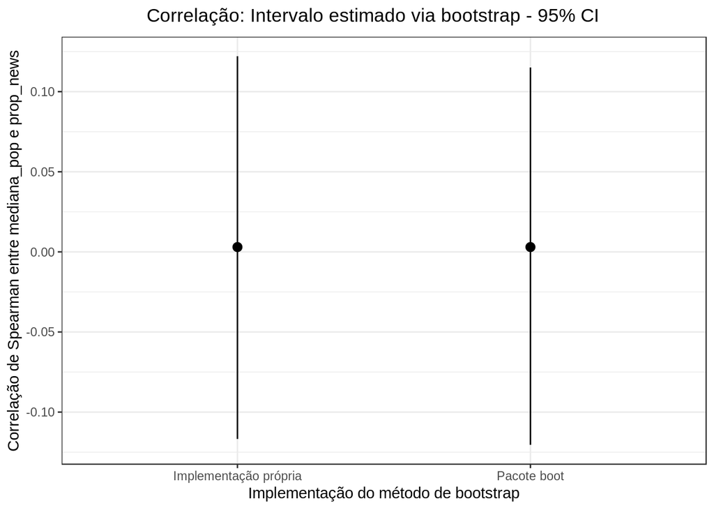

```r
ggplot() +
    geom_pointrange(aes(x = "Implementação própria",
                        y = theta_c_2,
                        ymin = intervalo_2$valor_i,
                        ymax = intervalo_2$valor_s
                    )) +
    geom_pointrange(aes(x = "Pacote boot",
                      y = ci_2$statistic,
                      ymin = ci_2$conf.low,
                      ymax = ci_2$conf.high
                      )) +
    geom_point(size = 3) +
    labs(x = "Implementação do método de bootstrap",
         y = "Correlação de Spearman entre mediana_pop e prop_news",
         title = expression("\t\tCorrelação: Intervalo estimado via bootstrap - 95% CI"))
```

A patir desta amostra estimamos que o coeficiente de correlação entre a métrica que indica a popularidade mediana dos artistas escutados e a métrica que indica a proporção dos artistas escutados que eram novos foi de $ 0.003$. A partir da análise do intervalo podemos afirmar com 95% de confiança ou que não há um correlação entre estas métricas, ou que há uma correlação *positiva fraca* ou que há uma correlação *negativa fraca*, pois o coeficiente de correlação na população fica entre $-0.12$ e $0.11$. Os valores para a implemtantação própria foram: $\hat\theta = 0.002998545$, $95\%$ CI [$-0.1167463, 0.1221119$] para a implementação própria e $\hat\theta = 0.002998545$, $95\%$ CI [$-0.1204292, 0.1150907$] para a estimação usando a biblioteca *boot*.